# *2019 NYC Airbnb Data Analysis*

# **Importing Libraries**

```python
#imports

#basics
import pandas as pd
import numpy as np

#visuals
import seaborn as sns
import matplotlib.pyplot as plt
sns.set()
import folium
from folium import plugins
from folium.plugins import HeatMap
```

# **Airbnb Dataset**

Here, my goal was to inspect and get a better understanding of the dataset I was working with.

```python
#summary of dataset
air_bnb = pd.read_csv ('AB_NYC_2019.csv')
air_bnb
```

|  | id | name | host_id | host_name | neighbourhood_group | neighbourhood | latitude | longitude | room_type | price | minimum_nights | number_of_reviews | last_review | reviews_per_month | calculated_host_listings_count | availability_365 |
| --- | --- | --- | --- | --- | --- | --- | --- | --- | --- | --- | --- | --- | --- | --- | --- | --- |
| 0 | 2539 | Clean & quiet apt home by the park | 2787 | John | Brooklyn | Kensington | 40.64749 | -73.97237 | Private room | 149 | 1 | 9 | 2018-10-19 | 0.21 | 6 | 365 |
| 1 | 2595 | Skylit Midtown Castle | 2845 | Jennifer | Manhattan | Midtown | 40.75362 | -73.98377 | Entire home/apt | 225 | 1 | 45 | 2019-05-21 | 0.38 | 2 | 355 |
| 2 | 3647 | THE VILLAGE OF HARLEM....NEW YORK ! | 4632 | Elisabeth | Manhattan | Harlem | 40.80902 | -73.94190 | Private room | 150 | 3 | 0 | NaN | NaN | 1 | 365 |
| 3 | 3831 | Cozy Entire Floor of Brownstone | 4869 | LisaRoxanne | Brooklyn | Clinton Hill | 40.68514 | -73.95976 | Entire home/apt | 89 | 1 | 270 | 2019-07-05 | 4.64 | 1 | 194 |
| 4 | 5022 | Entire Apt: Spacious Studio/Loft by central park | 7192 | Laura | Manhattan | East Harlem | 40.79851 | -73.94399 | Entire home/apt | 80 | 10 | 9 | 2018-11-19 | 0.10 | 1 | 0 |
| ... | ... | ... | ... | ... | ... | ... | ... | ... | ... | ... | ... | ... | ... | ... | ... | ... |
| 48890 | 36484665 | Charming one bedroom - newly renovated rowhouse | 8232441 | Sabrina | Brooklyn | Bedford-Stuyvesant | 40.67853 | -73.94995 | Private room | 70 | 2 | 0 | NaN | NaN | 2 | 9 |
| 48891 | 36485057 | Affordable room in Bushwick/East Williamsburg | 6570630 | Marisol | Brooklyn | Bushwick | 40.70184 | -73.93317 | Private room | 40 | 4 | 0 | NaN | NaN | 2 | 36 |
| 48892 | 36485431 | Sunny Studio at Historical Neighborhood | 23492952 | Ilgar & Aysel | Manhattan | Harlem | 40.81475 | -73.94867 | Entire home/apt | 115 | 10 | 0 | NaN | NaN | 1 | 27 |
| 48893 | 36485609 | 43rd St. Time Square-cozy single bed | 30985759 | Taz | Manhattan | Hell's Kitchen | 40.75751 | -73.99112 | Shared room | 55 | 1 | 0 | NaN | NaN | 6 | 2 |
| 48894 | 36487245 | Trendy duplex in the very heart of Hell's Kitchen | 68119814 | Christophe | Manhattan | Hell's Kitchen | 40.76404 | -73.98933 | Private room | 90 | 7 | 0 | NaN | NaN | 1 | 23 |

48895 rows × 16 columns

```python
#info regarding the dataset
air_bnb.info()
```

```
<class 'pandas.core.frame.DataFrame'>
RangeIndex: 48895 entries, 0 to 48894
Data columns (total 16 columns):
 #   Column                          Non-Null Count  Dtype
---  ------                          --------------  -----
 0   id                              48895 non-null  int64
 1   name                            48879 non-null  object
 2   host_id                         48895 non-null  int64
 3   host_name                       48874 non-null  object
 4   neighbourhood_group             48895 non-null  object
 5   neighbourhood                   48895 non-null  object
 6   latitude                        48895 non-null  float64
 7   longitude                       48895 non-null  float64
 8   room_type                       48895 non-null  object
 9   price                           48895 non-null  int64
 10  minimum_nights                  48895 non-null  int64
 11  number_of_reviews               48895 non-null  int64
 12  last_review                     38843 non-null  object
 13  reviews_per_month               38843 non-null  float64
 14  calculated_host_listings_count  48895 non-null  int64
 15  availability_365                48895 non-null  int64
dtypes: float64(3), int64(7), object(6)
memory usage: 6.0+ MB
```

```python
#statistics for numercial values in dataset
air_bnb.describe()
```

|  | id | host_id | latitude | longitude | price | minimum_nights | number_of_reviews | reviews_per_month | calculated_host_listings_count | availability_365 |
| --- | --- | --- | --- | --- | --- | --- | --- | --- | --- | --- |
| count | 4.889500e+04 | 4.889500e+04 | 48895.000000 | 48895.000000 | 48895.000000 | 48895.000000 | 48895.000000 | 38843.000000 | 48895.000000 | 48895.000000 |
| mean | 1.901714e+07 | 6.762001e+07 | 40.728949 | -73.952170 | 152.720687 | 7.029962 | 23.274466 | 1.373221 | 7.143982 | 112.781327 |
| std | 1.098311e+07 | 7.861097e+07 | 0.054530 | 0.046157 | 240.154170 | 20.510550 | 44.550582 | 1.680442 | 32.952519 | 131.622289 |
| min | 2.539000e+03 | 2.438000e+03 | 40.499790 | -74.244420 | 0.000000 | 1.000000 | 0.000000 | 0.010000 | 1.000000 | 0.000000 |
| 25% | 9.471945e+06 | 7.822033e+06 | 40.690100 | -73.983070 | 69.000000 | 1.000000 | 1.000000 | 0.190000 | 1.000000 | 0.000000 |
| 50% | 1.967728e+07 | 3.079382e+07 | 40.723070 | -73.955680 | 106.000000 | 3.000000 | 5.000000 | 0.720000 | 1.000000 | 45.000000 |
| 75% | 2.915218e+07 | 1.074344e+08 | 40.763115 | -73.936275 | 175.000000 | 5.000000 | 24.000000 | 2.020000 | 2.000000 | 227.000000 |
| max | 3.648724e+07 | 2.743213e+08 | 40.913060 | -73.712990 | 10000.000000 | 1250.000000 | 629.000000 | 58.500000 | 327.000000 | 365.000000 |

# **Data Cleaning**

```python
#dropping unwanted columns
air_bnb.drop(['id','host_id', 'calculated_host_listings_count','last_review'],axis=1).describe(include='all')
```

|  | name | host_name | neighbourhood_group | neighbourhood | latitude | longitude | room_type | price | minimum_nights | number_of_reviews | reviews_per_month | availability_365 |
| --- | --- | --- | --- | --- | --- | --- | --- | --- | --- | --- | --- | --- |
| count | 48879 | 48874 | 48895 | 48895 | 48895.000000 | 48895.000000 | 48895 | 48895.000000 | 48895.000000 | 48895.000000 | 38843.000000 | 48895.000000 |
| unique | 47905 | 11452 | 5 | 221 | NaN | NaN | 3 | NaN | NaN | NaN | NaN | NaN |
| top | Hillside Hotel | Michael | Manhattan | Williamsburg | NaN | NaN | Entire home/apt | NaN | NaN | NaN | NaN | NaN |
| freq | 18 | 417 | 21661 | 3920 | NaN | NaN | 25409 | NaN | NaN | NaN | NaN | NaN |
| mean | NaN | NaN | NaN | NaN | 40.728949 | -73.952170 | NaN | 152.720687 | 7.029962 | 23.274466 | 1.373221 | 112.781327 |
| std | NaN | NaN | NaN | NaN | 0.054530 | 0.046157 | NaN | 240.154170 | 20.510550 | 44.550582 | 1.680442 | 131.622289 |
| min | NaN | NaN | NaN | NaN | 40.499790 | -74.244420 | NaN | 0.000000 | 1.000000 | 0.000000 | 0.010000 | 0.000000 |
| 25% | NaN | NaN | NaN | NaN | 40.690100 | -73.983070 | NaN | 69.000000 | 1.000000 | 1.000000 | 0.190000 | 0.000000 |
| 50% | NaN | NaN | NaN | NaN | 40.723070 | -73.955680 | NaN | 106.000000 | 3.000000 | 5.000000 | 0.720000 | 45.000000 |
| 75% | NaN | NaN | NaN | NaN | 40.763115 | -73.936275 | NaN | 175.000000 | 5.000000 | 24.000000 | 2.020000 | 227.000000 |
| max | NaN | NaN | NaN | NaN | 40.913060 | -73.712990 | NaN | 10000.000000 | 1250.000000 | 629.000000 | 58.500000 | 365.000000 |

```python
#changing column names for better clarity
air_bnb = air_bnb.rename(columns={'neighbourhood_group': 'borough',
                            'neighbourhood': 'neighborhood'})
air_bnb.columns
```

```
Index(['id', 'name', 'host_id', 'host_name', 'borough', 'neighborhood',
       'latitude', 'longitude', 'room_type', 'price', 'minimum_nights',
       'number_of_reviews', 'last_review', 'reviews_per_month',
       'calculated_host_listings_count', 'availability_365'],
      dtype='object')
```

# **Dealing with missing values**

As an extension of data cleaning, I checked for missing values in the dataset and then removed them to eliminate any inconsistencies in my analysis.

```python
#checking null values
air_bnb.isna().sum()
```

```
id                                    0
name                                 16
host_id                               0
host_name                            21
borough                               0
neighborhood                          0
latitude                              0
longitude                             0
room_type                             0
price                                 0
minimum_nights                        0
number_of_reviews                     0
last_review                       10052
reviews_per_month                 10052
calculated_host_listings_count        0
availability_365                      0
dtype: int64
```

```python
#droppig null values
cleaned_airbnb = air_bnb.dropna(axis = 0, how ='any')
np.sum(cleaned_airbnb.isnull())
```

```
id                                0
name                              0
host_id                           0
host_name                         0
borough                           0
neighborhood                      0
latitude                          0
longitude                         0
room_type                         0
price                             0
minimum_nights                    0
number_of_reviews                 0
last_review                       0
reviews_per_month                 0
calculated_host_listings_count    0
availability_365                  0
dtype: int64
```

# **Analyzing and visualizing data to make inferences**

Now, I was ready to begin analyzing and visualizing the data. Ultilizing a variety of tools, e.g., charts, tables, and maps, I was able to make strong conclusions regarding NYC Airbnb's in 2019.

## 1. Airbnb Locations

```python
set(air_bnb['borough'])
```

```
{'Bronx', 'Brooklyn', 'Manhattan', 'Queens', 'Staten Island'}
```

```python
#Count of listings in each borough
borough_listings = air_bnb.groupby('borough')['name'].count().sort_values(ascending = False)
borough_listings
```

```
borough
Manhattan        21652
Brooklyn         20098
Queens            5666
Bronx             1090
Staten Island      373
Name: name, dtype: int64
```

[figure not shown]

```python
#Plotting a Bar Chart
borough_listings.plot(kind = 'bar', title = 'Airbnb Listings by Borough',  figsize=(16,6), color = '#0000FF')
plt.ylabel('# of Listings', fontdict= {'size':10})
plt.xlabel('Borough', fontdict= {'size':10})
```

```python
#Heatmap showing location of listings
airbnb_map = folium.Map(location=[40.7, -74],zoom_start =10)
airbnb_loc = air_bnb[['latitude','longitude']].values
airbnb_loc = airbnb_loc.tolist()
hm = plugins.HeatMap(airbnb_loc)
hm.add_to(airbnb_map)
airbnb_map
```

Make this Notebook Trusted to load map: File -> Trust Notebook

[interactive chart not shown]

```python
#Top 5 neighborhood listings in each borough
borough = air_bnb.borough.unique()
for n in borough:
    print(f'Top 5 neighborhood in borough {n}')
    print(air_bnb.loc[air_bnb['borough']==n]['neighborhood'].value_counts()[:5])
    print()
```

```
Top 5 neighborhood in borough Brooklyn
Williamsburg          3920
Bedford-Stuyvesant    3714
Bushwick              2465
Crown Heights         1564
Greenpoint            1115
Name: neighborhood, dtype: int64

Top 5 neighborhood in borough Manhattan
Harlem             2658
Upper West Side    1971
Hell's Kitchen     1958
East Village       1853
Upper East Side    1798
Name: neighborhood, dtype: int64

Top 5 neighborhood in borough Queens
Astoria             900
Long Island City    537
Flushing            426
Ridgewood           423
Sunnyside           363
Name: neighborhood, dtype: int64

Top 5 neighborhood in borough Staten Island
St. George       48
Tompkinsville    42
Stapleton        27
Concord          26
Arrochar         21
Name: neighborhood, dtype: int64

Top 5 neighborhood in borough Bronx
Kingsbridge    70
Fordham        63
Longwood       62
Mott Haven     60
Concourse      50
Name: neighborhood, dtype: int64
```

## 2. Airbnb Room Types & Prices

```python
#Room type by percentages
room_type_percentage = (air_bnb['room_type'].value_counts()/air_bnb.shape[0])*100
room_type_percentage
```

```
Entire home/apt    51.966459
Private room       45.661111
Shared room         2.372431
Name: room_type, dtype: float64
```

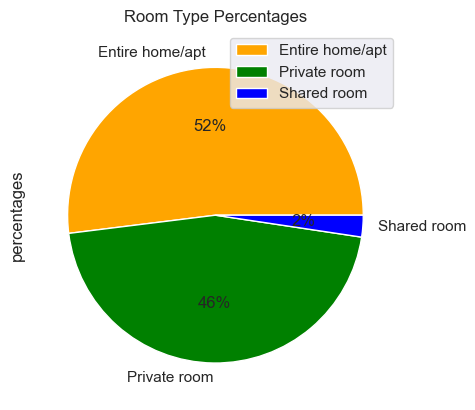

```python
#Plotting room type percentages on a pie chart
air_bnb = pd.DataFrame({'room_type': ['Entire home/apt', 'Private room', 'Shared room'],
                   'percentages': [51.97, 45.67, 2.37]})

air_bnb.groupby(['room_type']).sum().plot(kind='pie', y='percentages', autopct='%1.0f%%',
                                colors = ['orange', 'green', 'blue'],
                                title='Room Type Percentages')
```

```python
bnb_price_sum = air_bnb.price.sum()
bnbs = len(air_bnb.index)
avg_price = int(bnb_price_sum)/bnbs
print("The average bnb room price across all of New York is ${:.2f}".format(avg_price))
```

```
The average bnb room price across all of New York is $152.72
```

```python
air_bnb.pivot_table(index='borough',columns='room_type',values='price',aggfunc='mean')
```

| room_type borough | Entire home/apt | Private room | Shared room |
| --- | --- | --- | --- |
| Bronx | 127.506596 | 66.788344 | 59.800000 |
| Brooklyn | 178.327545 | 76.500099 | 50.527845 |
| Manhattan | 249.239109 | 116.776622 | 88.977083 |
| Queens | 147.050573 | 71.762456 | 69.020202 |
| Staten Island | 173.846591 | 62.292553 | 57.444444 |

```python
air_bnb.groupby('room_type')['price'].mean()
```

```
room_type
Entire home/apt    211.794246
Private room        89.780973
Shared room         70.127586
Name: price, dtype: float64
```

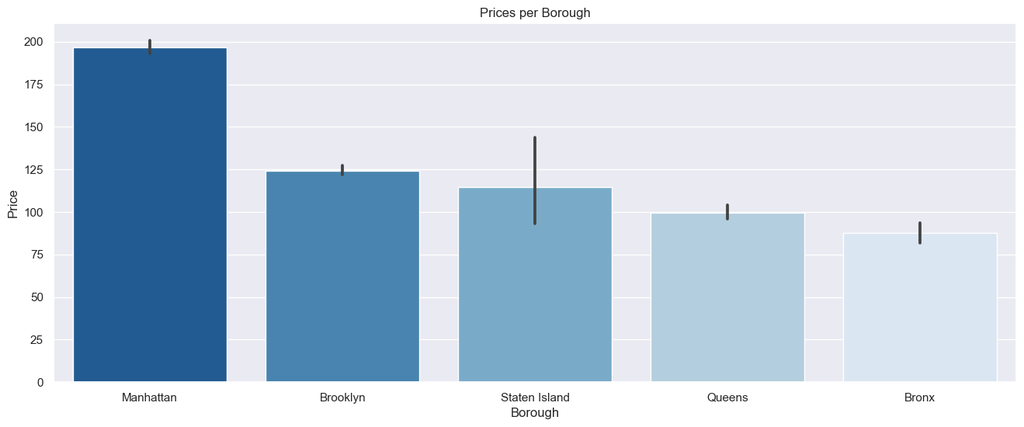

```python
plt.figure(figsize=(16,6))
sns.barplot(data=air_bnb, x='borough', y='price',
            order=['Manhattan','Brooklyn','Staten Island', 'Queens', 'Bronx'],
            palette = 'Blues_r')
plt.xlabel("Borough")
plt.ylabel("Price")
plt.title("Prices per Borough")
plt.show()
```